# Stacked bar plot at genus level – Yu, Yi

Jia, Xiu

07 April, 2022

This is the script for generating Figure S6 in Yu et al. Molecular Cell (2022).

### Initiate libraries

```r
library(tidyverse)
library(RColorBrewer)
library(reshape2)
```

### set plot theme

```r
rm(list=ls())

mytheme <- theme_bw()+
  theme(text = element_text(size = 10),
        panel.spacing = unit(0, "lines"),
        strip.background = element_blank(),
        strip.placement = "outside",
        legend.box.background = element_rect(),
        legend.box.margin = margin(1, 1, 1, 1),
        legend.text = element_text(face = "italic"),
        legend.position = "right",
        panel.grid.major = element_blank(),
        panel.grid.minor = element_blank(),
        plot.margin=unit(c(1, 0.5, 1, 0.5),"cm"))
```

### 1 import dataset

```r
# load feature/OTU table
com <- read.csv("feature-table-rarified-nontax.tsv", sep="\t", header=1, row.names=1, check.names = FALSE)

# replace hypen by underscore
colnames(com) <- gsub(colnames(com), pattern = '\\-', replacement = '_')
com <- t(com)

# only keep samples that belongs to L3 and heterozygous
com<- com[grepl("L3", row.names(com)),]
com<- com[grepl("heterozygous", row.names(com)),]
com <- t(com)
com[1:5, 1:2]
```

```
##                                  L3_Control_heterozygous_1
## 97e0585fc64c41f405d7c9b59fc192fd                         0
## 1dca96eaa7f8f2ffec2d74b80ccb9111                         0
## 527e7463681441e64266e13d4e8f1ff0                         0
## 88102669f67ed8611f26d5251bfcf020                         0
## 7e2665cb299c69a3bb18b330920d837b                         0
##                                  L3_Control_heterozygous_2
## 97e0585fc64c41f405d7c9b59fc192fd                         0
## 1dca96eaa7f8f2ffec2d74b80ccb9111                         0
## 527e7463681441e64266e13d4e8f1ff0                         0
## 88102669f67ed8611f26d5251bfcf020                         0
## 7e2665cb299c69a3bb18b330920d837b                         0
```

```r
# load taxonomy table
taxa <- read.csv("taxonomy.csv", sep = ",", row.names = 1, header = TRUE)
taxa <- taxa[row.names(taxa) %in% row.names(com), ]
head(taxa)
```

```
##                                    Domain         Phylum               Class
## 13e31540432f65cb5f06fcde85b69c8b Bacteria Proteobacteria Alphaproteobacteria
## e12effb6ec1fdeb2f4b3fc5ac9a691ad Bacteria Proteobacteria Alphaproteobacteria
## 35a7a7077a26370ac466525b70d44629 Bacteria Proteobacteria Alphaproteobacteria
## 244f5cdd01dcd44bd6dc9736eb23cbbf Bacteria Proteobacteria Alphaproteobacteria
## 0566a9753a856f3db23ef7b6a2d93ebc Bacteria Proteobacteria Alphaproteobacteria
## 1b1092e1ea11e2631434447639629423 Bacteria Proteobacteria Alphaproteobacteria
##                                            Order           Family       Genus
## 13e31540432f65cb5f06fcde85b69c8b Acetobacterales Acetobacteraceae Acetobacter
## e12effb6ec1fdeb2f4b3fc5ac9a691ad Acetobacterales Acetobacteraceae Acetobacter
## 35a7a7077a26370ac466525b70d44629 Acetobacterales Acetobacteraceae Acetobacter
## 244f5cdd01dcd44bd6dc9736eb23cbbf Acetobacterales Acetobacteraceae Acetobacter
## 0566a9753a856f3db23ef7b6a2d93ebc Acetobacterales Acetobacteraceae Acetobacter
## 1b1092e1ea11e2631434447639629423 Acetobacterales Acetobacteraceae Acetobacter
##                                  Species Confidence
## 13e31540432f65cb5f06fcde85b69c8b          0.9975549
## e12effb6ec1fdeb2f4b3fc5ac9a691ad          0.9975549
## 35a7a7077a26370ac466525b70d44629          0.9975611
## 244f5cdd01dcd44bd6dc9736eb23cbbf          0.9975692
## 0566a9753a856f3db23ef7b6a2d93ebc          0.9975506
## 1b1092e1ea11e2631434447639629423          0.9972080
```

In the end, we got 23 samples and 295 ASVs for the L3 stage and heterozygous samples. The total abundance per sample range: 1100, 1100, 1100, 1100, 1100, 1100, 1100, 1100, 1100, 1100, 1100, 1100, 1100, 1100, 1100, 1100, 1100, 1100, 1100, 1100, 1100, 1100, 1100.

### 2 summarize data

Calculate relative abundance for each genus. Only keep taxa with relative abundance > 0.05% for final plotting

```r
# combine otu table and taxa info
df <- transform(merge(taxa, com, by="row.names"), row.names=Row.names, Row.names=NULL)

# only keep Genus column
df <- df[, -c(1:5, 7, 8)]
df[1:5, 1:2]
```

```
##                                                   Genus
## 01aa813a4ee64c7277c346f108479043 Candidatus Udaeobacter
## 02950c88e51ba7e2270d8ef4f2cefc1c          Enhydrobacter
## 032e95f99a5638ffb73574c69028afe5                   RB41
## 03471147965722c298abbc31c1b87c6d            Brachymonas
## 034bfe7ab10b5abc3503b5e6273262fe        Novosphingobium
##                                  L3_Control_heterozygous_1
## 01aa813a4ee64c7277c346f108479043                         0
## 02950c88e51ba7e2270d8ef4f2cefc1c                         0
## 032e95f99a5638ffb73574c69028afe5                         0
## 03471147965722c298abbc31c1b87c6d                         0
## 034bfe7ab10b5abc3503b5e6273262fe                         0
```

```r
warning("double check is the table rarified or not?")
(rarefactiondepth <- mean(colSums(com)))
```

```
## [1] 1100
```

```r
# combine ASVs have same taxonomy
df <- aggregate(df[,-1], list(df$Genus), sum)
row.names(df) <- df$Group.1
df <- df[, -1]
df <- 100*df/rarefactiondepth

# only keep taxa with relative abundance > 0.05%
df$mean <- rowMeans(df)
df <- subset(df, mean > 0.05)
df <- df[with(df, order(mean)), ]
df$mean <- NULL
```

In the end, we got the following Genus with avarage relative abundance > 0.05%: Akkermansia, Lachnospiraceae NK4A136 group, Parabacteroides, Butyricimonas, uncultured bacterium, Staphylococcus, Acinetobacter, Enterococcus, , Bacteroides, Corynebacterium, Leuconostoc, Lactobacillus, Acetobacter

### 3 clean the data set and prepare data for plotting

```r
# remove rows that was not assigend at genus level
df <- df[-9, ]
df <- t(df)
df <- as.data.frame(df)

# remove "uncultured bacterium"
df$`uncultured bacterium` <- NULL

# add a column for Others (such as ASVs that are not assigned at Genus level or Genera with abundance less than 0.1%)
df1 <- df %>% rownames_to_column('sample')

df1 <- df1 %>%  mutate(Others = (100- rowSums(df1[, -1]))) %>%
  column_to_rownames('sample')

# move the last column to the start
df1 <- df1 %>%
  select(Others, everything())

head(df1)
```

```
##                              Others Akkermansia Lachnospiraceae NK4A136 group
## L3_Control_heterozygous_1 1.9090909           0                             0
## L3_Control_heterozygous_2 0.1818182           0                             0
## L3_Control_heterozygous_3 0.4545455           0                             0
## L3_Control_heterozygous_4 0.2727273           0                             0
## L3_Control_heterozygous_5 0.3636364           0                             0
## L3_Control_heterozygous_6 0.6363636           0                             0
##                           Parabacteroides Butyricimonas Staphylococcus
## L3_Control_heterozygous_1               0             0              0
## L3_Control_heterozygous_2               0             0              0
## L3_Control_heterozygous_3               0             0              0
## L3_Control_heterozygous_4               0             0              0
## L3_Control_heterozygous_5               0             0              0
## L3_Control_heterozygous_6               0             0              0
##                           Acinetobacter Enterococcus Bacteroides
## L3_Control_heterozygous_1     0.0000000            0           0
## L3_Control_heterozygous_2     0.0000000            0           0
## L3_Control_heterozygous_3     0.0000000            0           0
## L3_Control_heterozygous_4     0.0000000            0           0
## L3_Control_heterozygous_5     0.0000000            0           0
## L3_Control_heterozygous_6     0.9090909            0           0
##                           Corynebacterium Leuconostoc Lactobacillus Acetobacter
## L3_Control_heterozygous_1      0.72727273    0.000000     17.545455    79.81818
## L3_Control_heterozygous_2      0.09090909    0.000000      6.454545    93.27273
## L3_Control_heterozygous_3      0.00000000    1.000000      5.636364    92.90909
## L3_Control_heterozygous_4      0.00000000    1.090909      3.909091    94.72727
## L3_Control_heterozygous_5      0.00000000    1.181818     14.090909    84.36364
## L3_Control_heterozygous_6      0.00000000    1.272727      5.818182    91.36364
```

### 4 Torture the data to show less Acetobactor

As Acetobactor is the dominant genus, the variation of other genera is hard to see. So we deduct a number (60%) for the relative abundance of Acetobactor for plotting. Later on, we add a break in the y-axis manualy in Adobe Illustrator.

```r
df1$Acetobacter <- df1$Acetobacter - 60

# melt data.frame
df1 <- melt(as.matrix(df1))

# add group information
df1 <- df1 %>%
  separate(Var1, c("Stage", "Treatments", "Genotype", "Replicates"), "_")

df1$Treatments[df1$Treatments == 'VitaminB5'] <- 'Pantothenate'

# df1 <- df1[order(df1$Treatments),]
#
# df1 <- df1 %>% arrange(desc(Treatments))

df1$Groups <-  factor(paste(df1$Treatments, df1$Replicates, sep = "_"), level = c("Pantothenate_1", "Pantothenate_2", "Pantothenate_3", "Pantothenate_4", "Pantothenate_5", "Pantothenate_6", "Pantothenate_7", "Pantethine_1", "Pantethine_2",  "Pantethine_3",  "Pantethine_4","Pantethine_5",  "Pantethine_6", "Pantethine_7","Pantethine_8", "Control_1", "Control_2", "Control_3",    "Control_4", "Control_5", "Control_6", "Control_7", "Control_8"))

head(df1)
```

```
##   Stage Treatments     Genotype Replicates   Var2     value    Groups
## 1    L3    Control heterozygous          1 Others 1.9090909 Control_1
## 2    L3    Control heterozygous          2 Others 0.1818182 Control_2
## 3    L3    Control heterozygous          3 Others 0.4545455 Control_3
## 4    L3    Control heterozygous          4 Others 0.2727273 Control_4
## 5    L3    Control heterozygous          5 Others 0.3636364 Control_5
## 6    L3    Control heterozygous          6 Others 0.6363636 Control_6
```

```r
str(df1)
```

```
## 'data.frame':    299 obs. of  7 variables:
##  $ Stage     : chr  "L3" "L3" "L3" "L3" ...
##  $ Treatments: chr  "Control" "Control" "Control" "Control" ...
##  $ Genotype  : chr  "heterozygous" "heterozygous" "heterozygous" "heterozygous" ...
##  $ Replicates: chr  "1" "2" "3" "4" ...
##  $ Var2      : Factor w/ 13 levels "Others","Akkermansia",..: 1 1 1 1 1 1 1 1 1 1 ...
##  $ value     : num  1.909 0.182 0.455 0.273 0.364 ...
##  $ Groups    : Factor w/ 23 levels "Pantothenate_1",..: 16 17 18 19 20 21 22 23 8 9 ...
```

### 5 stacked bar plot

```r
# colour code
set.seed(2333)
(colourCount = length(unique(df1$Var2)))
```

```
## [1] 13
```

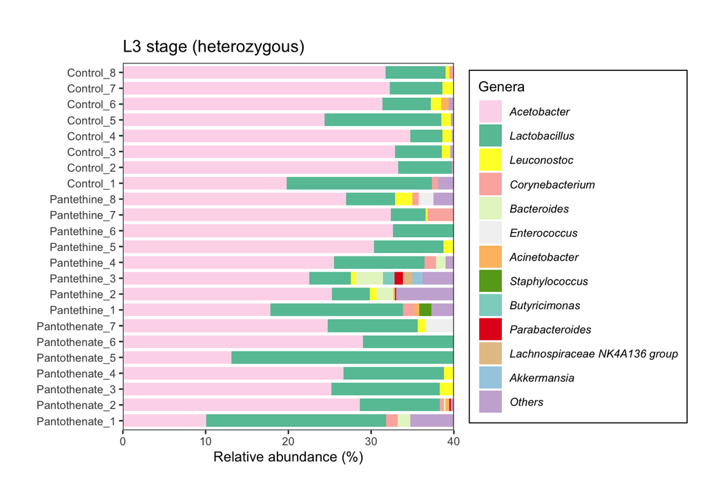

```r
qual_col_pals <- brewer.pal.info[brewer.pal.info$category == 'qual',]
col_vector <- unlist(mapply(brewer.pal, qual_col_pals$maxcolors, rownames(qual_col_pals)))
col <- sample(col_vector, colourCount)
# pie(rep(1,colourCount), col=sample(col_vector, colourCount))

# stacked-bar plot
(p2 <- ggplot(df1, aes(x = Groups, y = value, fill = Var2)) +
    geom_bar(stat = "identity", width = 0.8) +
    scale_y_continuous(expand = c(0, 0)) +
    scale_fill_manual(values = col) +
    labs(x = "", y = "Relative abundance (%)", title = "L3 stage (heterozygous)") +
    guides(fill = guide_legend(title="Genera", reverse = TRUE)) +
    coord_flip() +
    mytheme)
```

```r
ggsave("stacked_barplots_L3_heterozygous_genera_more_than_0.05.pdf", width = 12, height = 8.5, units = "cm", p2, scale = 1.5)
```

@Yi Please edit the raw figure in AI by adding the break in the x-axis. Where relative abundance is 10%, it should be 70%.